# Chapter 3

The analysis and results of week 3 are presented below.

```r
library(tidyverse)
data = read_csv('data/student_all.csv', show_col_types = FALSE)
colnames(data)
```

```
##  [1] "school"     "sex"        "age"        "address"    "famsize"
##  [6] "Pstatus"    "Medu"       "Fedu"       "Mjob"       "Fjob"
## [11] "reason"     "guardian"   "traveltime" "studytime"  "schoolsup"
## [16] "famsup"     "activities" "nursery"    "higher"     "internet"
## [21] "romantic"   "famrel"     "freetime"   "goout"      "Dalc"
## [26] "Walc"       "health"     "failures.x" "paid.x"     "absences.x"
## [31] "G1.x"       "G2.x"       "G3.x"       "failures.y" "paid.y"
## [36] "absences.y" "G1.y"       "G2.y"       "G3.y"       "alc_use"
## [41] "high_use"
```

The data contains information of 370 students who have participated on a mathematics course and a portuguese course. 27 first variables contain background information of the students. Variable ‘failure’ contains the number of past class failures, ‘absence’ the number of absences, ‘paid’ if extra classes have been paid for the course and G1-G3 the grades for first and second period and in total, for Mathematics (x) and Portuguese (y) respectively. Variable ‘alc_use’ describes the alcohol consumption (1= very low, 5= very high) and ‘high_use’ indicates if alc_use > 2.

I study the relationship between high alcohol consumption and final grades and absences on both courses (G3.x, absences.x, G3.y, absences.y). I assume that high alcohol consumption might correlate with lower grades and greater number of absences.

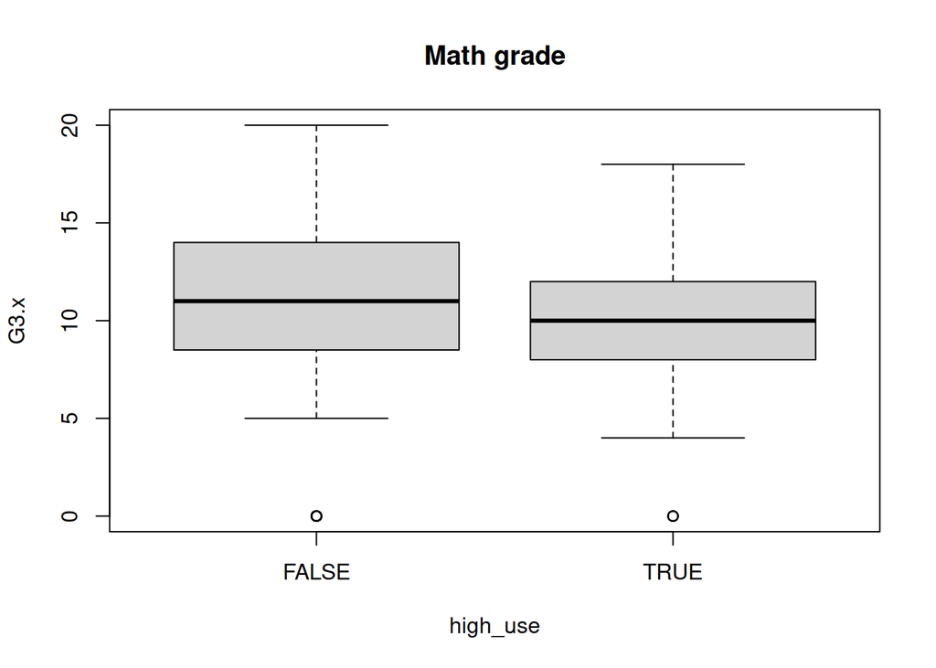

```r
boxplot(G3.x ~ high_use, data=data, main = "Math grade")
```

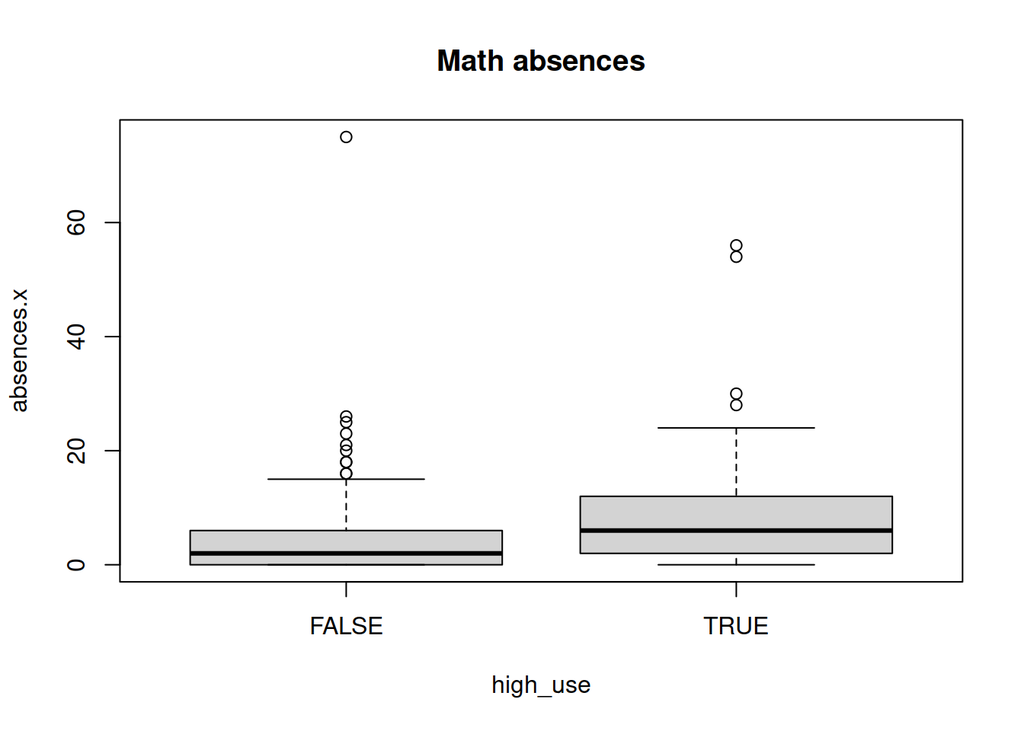

```r
boxplot(absences.x ~ high_use, data=data, main = "Math absences")
```

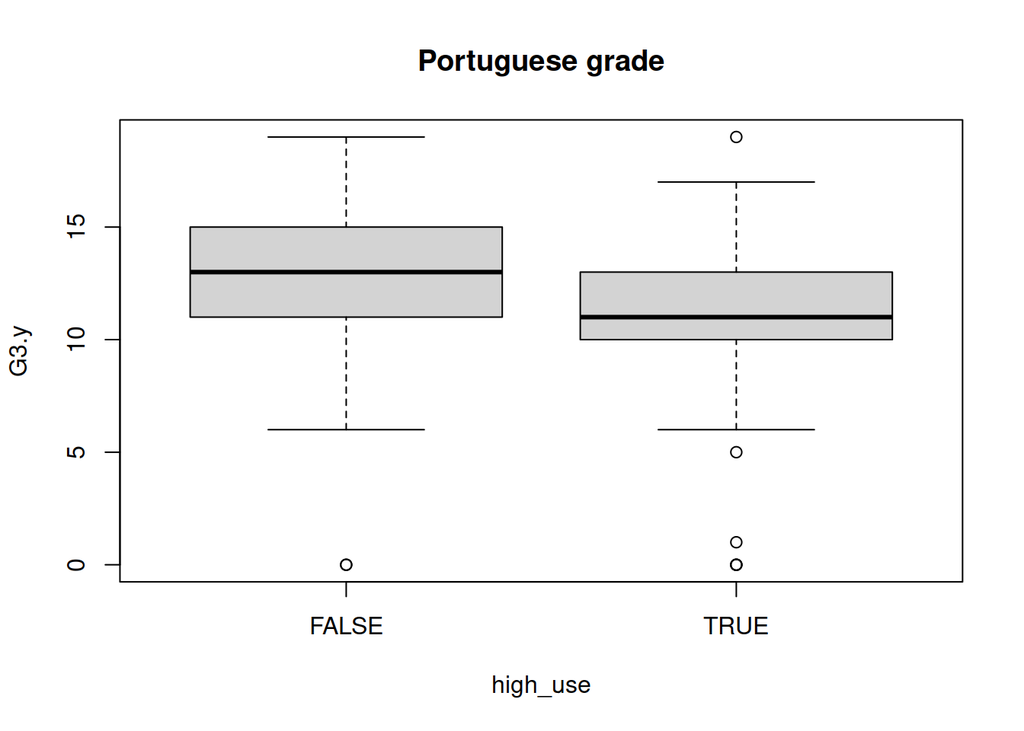

```r
boxplot(G3.y ~ high_use, data=data, main = "Portuguese grade")
```

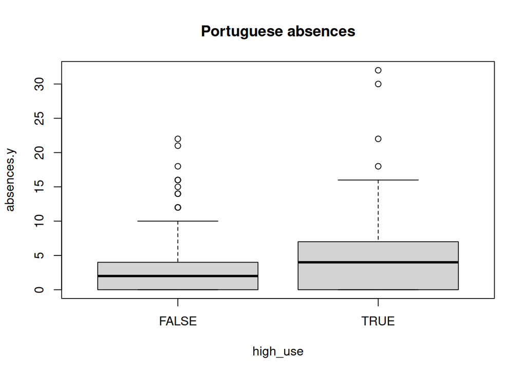

```r
boxplot(absences.y ~ high_use, data=data, main = "Portuguese absences")
```

```r
aggregate(data[, c('G3.x', 'absences.x', 'G3.y', 'absences.y')], list(data$high_use), mean)
```

```
##   Group.1     G3.x absences.x     G3.y absences.y
## 1   FALSE 10.60232   4.332046 12.99228   3.081081
## 2    TRUE 10.14414   7.828829 11.53153   4.918919
```

Based on the exploration, the initial hypothesis seems to be true. Grades for low_use group are slightly higher on both courses (10.6 vs 10.1 and 13.0 vs 11.5) and absences are lower (4.3 vs 7.8 and 3.1 vs 4.9).

I fit an logistic regression model to study the dependence between high alcohol usage and aforementioned four variables describing school performance. (Note that even though high alcohol usage is here used as a target variable and the school performance as explanatory variables, the model does not state anything about causality and in real world the possible causality between the variables might probably go the other way around!)

```r
model <- glm(high_use ~ G3.x+absences.x+G3.y+absences.y, data = data, family = binomial)
summary(model)
```

```
##
## Call:
## glm(formula = high_use ~ G3.x + absences.x + G3.y + absences.y,
##     family = binomial, data = data)
##
## Coefficients:
##             Estimate Std. Error z value Pr(>|z|)
## (Intercept)  0.67095    0.55309   1.213 0.225091
## G3.x         0.04636    0.03238   1.432 0.152172
## absences.x   0.04010    0.02028   1.977 0.048045 *
## G3.y        -0.19328    0.04970  -3.889 0.000101 ***
## absences.y   0.03921    0.02885   1.359 0.174194
## ---
## Signif. codes:  0 '***' 0.001 '**' 0.01 '*' 0.05 '.' 0.1 ' ' 1
##
## (Dispersion parameter for binomial family taken to be 1)
##
##     Null deviance: 452.04  on 369  degrees of freedom
## Residual deviance: 416.96  on 365  degrees of freedom
## AIC: 426.96
##
## Number of Fisher Scoring iterations: 4
```

```r
# Odds ratios and their confidence intervals:
exp(cbind(OR = coef(model), confint(model)))
```

```
##                    OR     2.5 %    97.5 %
## (Intercept) 1.9560973 0.6766933 5.9921960
## G3.x        1.0474534 0.9844994 1.1181947
## absences.x  1.0409158 1.0028173 1.0858484
## G3.y        0.8242486 0.7444620 0.9055192
## absences.y  1.0399855 0.9824006 1.1008298
```

In my model Portuguese course grade and Math course absences are the only statistically significant explanatory variables. This might be partially due to likely correlation between absences and grade of the course, which slightly violates the independence assumption of a logistic regression model.

Contradictory to the hypothesis and initial results, higher scores on math course seem to even indicate slightly higher probability of high alcohol usage. This is probably due to having too many explanatory variables, which are likely to have some amount of multicollinearity. It might be wise to remove some explanatory variables and try a simpler model.

```r
model2 <- glm(high_use ~ absences.x+G3.y, data = data, family = binomial)
summary(model2)
```

```
##
## Call:
## glm(formula = high_use ~ absences.x + G3.y, family = binomial,
##     data = data)
##
## Coefficients:
##             Estimate Std. Error z value Pr(>|z|)
## (Intercept)  0.81239    0.54258   1.497 0.134325
## absences.x   0.05702    0.01777   3.209 0.001333 **
## G3.y        -0.16092    0.04231  -3.803 0.000143 ***
## ---
## Signif. codes:  0 '***' 0.001 '**' 0.01 '*' 0.05 '.' 0.1 ' ' 1
##
## (Dispersion parameter for binomial family taken to be 1)
##
##     Null deviance: 452.04  on 369  degrees of freedom
## Residual deviance: 420.25  on 367  degrees of freedom
## AIC: 426.25
##
## Number of Fisher Scoring iterations: 4
```

```r
# Odds ratios and their confidence intervals:
exp(cbind(OR = coef(model2), confint(model2)))
```

```
##                    OR     2.5 %   97.5 %
## (Intercept) 2.2532861 0.7956532 6.754724
## absences.x  1.0586818 1.0246277 1.098323
## G3.y        0.8513564 0.7808634 0.922579
```

Now the model seems to be a little bit better. Let’s next predict for the data:

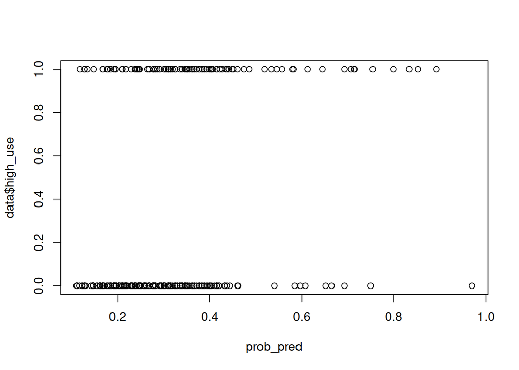

```r
prob_pred = model2 %>% predict(data, type = "response")
pred = prob_pred > 0.5
plot(prob_pred, data$high_use)
```

```r
table(pred, data$high_use)
```

```
##
## pred    FALSE TRUE
##   FALSE   250   94
##   TRUE      9   17
```

```r
#mean(pred==data$high_use)
```

Ideally the true cases (high users) on the top of the plot should be located more on the right than the false cases (low users). My model does not seem to perform very well in predicting alcohol usage based on school performance. The table shows the predicted negatives versus positives. Prediction is shown on rows and true condition on columns. 250 out of 259 low users are correctly classifies as low users, but only 17 of 111 high users are classified as high users.

```r
mean(pred==data$high_use)
```

```
## [1] 0.7216216
```

```r
mean(data$high_use == FALSE)
```

```
## [1] 0.7
```

The prediction from my model is correct in 72% of the cases. Purely by guessing the most common value (high_use = FALSE) for each student we get to accuracy of 70% so the model does not seem to be very useful :’(

The Bonus exercises sound interesting but unfortunately I didn’t have time to complete them.. :(